# Curso de introducción a la programación con Python

**Autor: Luis Fernando Apáez Álvarez**

## Proyecto 2 (parte II): Control de flujo

```python
# Paquetes que ocuparemos en esta parte del proyecto
import matplotlib.pyplot as mplot
import numpy as np
```

En la parte final de la primer parte de este proyecto probamos nuestro código creando el objeto `prueba`, donde ejecutamos el código

```
# Instanciamos la clase
prueba = graficar()

# Invocamos el método str
print(prueba.mensaje_inicial())

# Información dle usuario (proviene de la clase menu)
prueba.info_usuario()

# Método str (proviene de la clase graficar)
print(prueba)

# Graficamos (proviene de la clase graficar)
prueba.Graficador()
```

ejecutando dicho código en ese orden. Para este punto podemos notar que requerimos de cierto control de flujo en nuestras clases pues, como vemos en el código anterior, debemos primero ejecuar `print(prueba.mensaje_inicial())` y `prueba.info_usuario()` para que el resto del código funcione; asimismo, lo último que debe ejecutarse es el método `Graficador()`, pues de ejecutarse antes causará un error. Comenzaremos implementando primero un control de flujo en la clase `graficar`, donde por ejemplo desearemos que el método `str` deba ejecutarse primero antes que el método`Graficador()`.

Lo que haremos será definir un atributo con un valor lógico con el cual estableceremos el correcto control de flujo a la hora de llamar a los métodos de esta clase:

```python
class graficar(menu):
    def __init__(self):
        super().__init__()

        # Atributo lógico para el control de flujo
        self.control_f = False

    def __str__(self):
        # Cambiamos el valor lógico para poder ejecutar
        # el return de este método
        self.control_f = True

        return f'Rango:({self.rango_inf},{self.rango_sup})\nf(x) = {self.fun}'

    def Graficador(self):
        if self.control_f:
            x = np.arange(eval(self.rango_inf), eval(self.rango_sup), 0.01)
            y = self.fun
            mplot.plot(x, eval(y))
            mplot.grid()
            mplot.show()
        else:
            print("Debe ejecutarse primero el método str!")
```

lo anterior puede explicarse como:

- De forma inicial `self.control_f=False` de tal manera, si invocamos el método `Graficador()` antes del método `str`, `self.control_f` seguirá siendo falso. Por ende, debido al `if`, se imprimirá el mensaje `"Debe ejecutarse primero el método str!"`.
- Al invocar primero el método `str` cambiamos el valor de `self.control_f` a verdadero, de modo que, después de invocar el método `str`, podremos invocar el método `Graficador()` de forma correcta.

Hagamos una prueba:

```python
# Instanciamos la clase e ingresamos la información del usuario

prueba = graficar()
prueba.info_usuario()
```

```
______________________________
```

```python
# Invocamos el método Graficador antes del str
prueba.Graficador()
```

```
Debe ejecutarse primero el método str!
```

```
Rango:(0,1)
f(x) = x**2
```

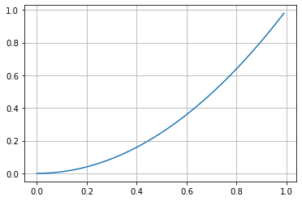

```python
# Correcto control de flujo:

# Invocamos primero el método str
print(prueba)

# Graficamos (proviene de la clase graficar)
prueba.Graficador()
```

Ahora bien, adaptaremos también la clase `menu` para adaptar un control de flujo con el siguiente orden:

1. Debe invocarse primero el método `mensaje_inicial`
2. Debe invocarse el método `info_usuario`
3. Debe invocarse el método `str` de la clase `graficar`
4. Al final, debe invocarse el método `Graficador()`

La idea para implementar lo anterior es análoga a lo que hicimos antes, salvo que el atributo `self.control_f` será parte del constructor de la super clase.

Así, escribimos

```python
class menu:
    def __init__(self):
        self.fun = ""
        self.rango = ""

        # Atributo para control de flujo
        self.control_f = False

    def mensaje_inicial(self):
        self.cadena1 = "De que tipo es tu función:"
        self.cadena2 = "_" * 30
        self.cadena3 = "1: Algebraicas"
        self.cadena4 = "2: Trigonométricas"
        self.cadena5 = "3: Exponencial"
        self.cadena6 = "4: Logarítmica"
        self.cadena7 = "_" * 30

        # Cambiamos valor lógico de control_f
        self.control_f = True

        return self.cadena1 + "\n" + self.cadena2 + "\n" + self.cadena3 \
    + "\n" + self.cadena4 + "\n" + self.cadena5 + "\n" + self.cadena6 \
    + "\n" + self.cadena7

    def info_usuario(self):

        # Implementamos el if para el control del flujo
        if self.control_f:
            self.n_aux = input("Coloca un número del 1 al 4: ")
            print("_" * 30)
            if int(self.n_aux) not in (1,2,3,4):
                print("Error, debes ingresar un número del 1 al 4")
                print("Fin del proceso")
            else:
                self.fun = input("Ingresa tu función: ")
                self.rango = input("Ingresa el rango de graficación: ")
                self.rango_inf = self.rango[self.rango.find("(") + 1: self.rango.find(",")]
                self.rango_sup = self.rango[self.rango.find(",") + 1: self.rango.find(")")]
            if int(self.n_aux) != 1:
                self.fun = "np." + self.fun
            else:
                self.fun = self.fun
        else:
            print("Debe invocarse primero el método mensaje inicial")
```

Notemos que al invocar el método `info_usuario()` de la clase menú, tendremos que `self.control_f` tendrá asignado el valor de `True`. Así, el control del flujo de la clase `graficar()` se verá afectado y podremos invocar el método `Graficador()` antes del método `str`. Para resolver este conflicto escribimos

```python
class graficar(menu):
    def __init__(self):
        super().__init__()
        # Cambiamos nuevamente el valor lógico de control_f

    def __str__(self):
        # Cambiamos el valor lógico para poder ejecutar
        # el return de este método
        self.control_f = False

        return f'Rango:({self.rango_inf},{self.rango_sup})\nf(x) = {self.fun}'

    def Graficador(self):
        if not self.control_f:
            x = np.arange(eval(self.rango_inf), eval(self.rango_sup), 0.01)
            y = self.fun
            mplot.plot(x, eval(y))
            mplot.grid()
            mplot.show()
        else:
            print("Debe ejecutarse primero el método str!")
```

es decir, como `self.control_f` tiene asignado el valor `True`, el método `Graficador()` sólo se ejecutará si `self.control_f` es `False`. Luego, el método `str` lo que hace es cambiar el valor de `True` de `control_f` a `False`, con lo cual conseguimos el control de flujo deseado. Hagamos unas pruebas:

```python
# Invocamos primero el método info_usuario antes del mensaje_inicial
prueba = graficar()
prueba.info_usuario()
```

```
Debe invocarse primero el método mensaje inicial
```

```python
# Correcto control de flujo en la clase Menu
print(prueba.mensaje_inicial())
prueba.info_usuario()
```

```
De que tipo es tu función:
______________________________
1: Algebraicas
2: Trigonométricas
3: Exponencial
4: Logarítmica
______________________________
```

```
______________________________
```

Probamos ahora el control de flujo en la clase `graficar()`

```python
# Invocamos el método graficar antes que el str
prueba.Graficador()
```

```
Debe ejecutarse primero el método str!
```

```
Rango:(0,1)
f(x) = x**2
```

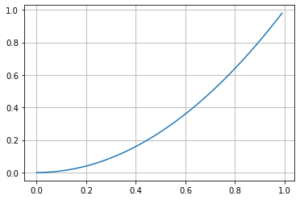

```python
# Correcto control de flujo
print(prueba)
prueba.Graficador()
```

Para finalizar esta parte del proyecto grafiquemos las siguientes funciones

```
De que tipo es tu función:
______________________________
1: Algebraicas
2: Trigonométricas
3: Exponencial
4: Logarítmica
______________________________
```

```
______________________________
```

```
Rango:(-np.pi,np.pi)
f(x) = np.cos(x)
```

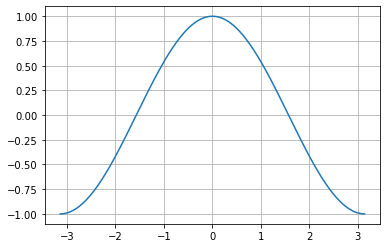

```
# Instanciamos la clase
prueba3 = graficar()

# Invocamos el método str
print(prueba3.mensaje_inicial())

# Información dle usuario (proviene de la clase menu)
prueba3.info_usuario()

# Método str (proviene de la clase graficar)
print(prueba3)

# Graficamos (proviene de la clase graficar)
prueba3.Graficador()
```

```
De que tipo es tu función:
______________________________
1: Algebraicas
2: Trigonométricas
3: Exponencial
4: Logarítmica
______________________________
```

```
______________________________
```

```
Rango:(1,5)
f(x) = np.log(x)
```

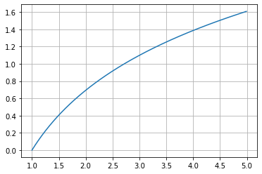

```python
# Instanciamos la clase
prueba2 = graficar()

# Invocamos el método str
print(prueba2.mensaje_inicial())

# Información dle usuario (proviene de la clase menu)
prueba2.info_usuario()

# Método str (proviene de la clase graficar)
print(prueba2)

# Graficamos (proviene de la clase graficar)
prueba2.Graficador()
```